# Rapid Affect Test Preliminary Analysis

[Krisya Louie](https://github.com/krislouie) - 03 November 2022

# Data overview

Load data, reorder columns, de-duplicate, check for missing data and create epidemiological weeks & time-of-day columns.

```r
df_raw <- import("19Oct2022_RAT.csv")
df_clean <- import("19Oct2022_eric_data.csv")
covid_data <- import("owid-covid-data.csv")
covid_data <- covid_data %>% filter(iso_code == "HKG")

df_clean <- df_clean %>% na_if(999)
df <- df_clean %>% clean_names()

# make factors
df <- df %>% mutate(gender = fct_recode(gender,
                                        "Male" = "Male",
                                        "Female" = "Female",
                                        "transgender" = "Transexual",
                                        "agender" = "Asexual",
                                        "bigender" = "Bisexual",
                                        "genderx" = "Gender X"),
                    gender = fct_lump_n(gender,2),
                    age_groups = fct_recode(as_factor(age_groups),
                                            "<9" = "1",
                                            "10-14" = "2",
                                            "15-19" = "3",
                                            "20-24" = "4",
                                            "25-29" = "5",
                                            "30-34" = "6",
                                            "35-39" = "7",
                                            "40-44" = "8",
                                            "45-49" = "9",
                                            "50-54" = "10",
                                            "55-59" = "11",
                                            "60-64" = "12",
                                            ">65" = "13"),
                    k6_tier = fct_relevel(as_factor(k6_tier),
                                          "No risk", "Low risk", "Moderate risk", "High risk"),
                    caught_covid = as.numeric(as.factor(caught_covid))-1,
                    family_covid = as.numeric(as.factor(family_covid))-1,
                    friend_covid = as.numeric(as.factor(friend_covid))-1,
                    quarantine = as.numeric(as.factor(quarantine))-1,
                    compul_testing = as.numeric(as.factor(compul_testing))-1,
                    lose_job = as.numeric(as.factor(lose_job))-1,
                    finance_difficulty = as.numeric(as.factor(finance_difficulty))-1,
                    others = as.numeric(as.factor(others))-1,
                    caught_covid_asymp = as.numeric(as.factor(caught_covid_asymp))-1,
                    resources_shortage = as.numeric(as.factor(resources_shortage))-1,
                    no_events = fct_relevel(no_events,"No COVID events", "At least 1 COVID event"),
                    hk_yn = fct_relevel(hk_yn,"in HK","not in HK"),
                    cohort_2 = fct_relevel(cohort_2,
                                           '1'='Cohort 1 (20Feb-24Feb)',
                                           '2'='Cohort 2 (25Feb-01Mar)',
                                           '3'='Cohort 3 (02Mar-06Mar)',
                                           '4'='Cohort 4 (07Mar-11Mar)',
                                           '5'='Cohort 5 (12Mar-22Mar)',
                                           '6'='Cohort 6 (23Mar-30Mar)',
                                           '7'='Cohort 7 (31Mar-20Apr)',
                                           '8'='Cohort 8 (21Apr-13Jun)',
                                           '9'='Cohort 9 (14Jun-19Oct'),
                    service_1 = fct_relevel(as_factor(service_1),
                                            "1" = "w/ service",
                                            "2" = "no service and not seeking",
                                            "3"= "no service and failed seeking"),
                    agegroup2 = fct_explicit_na(agegroup2, na_level = "Unknown"),
                    gender_yn = fct_recode(gender_yn,
                                            "0" = "Without Gender data", "1" = "With Gender data"),
                    age_yn = ifelse(is.na(age_groups), "0", "1"),
                    age_yn = fct_relevel(age_yn)
                    )

# pull date and time data
df <- df %>% mutate(start_date = ymd_hms(start_date),week = as_date(floor_date(start_date, unit = "week")), time_of_day = hour(start_date))

# new youth group column
df <- df %>% mutate(youth_group = case_when(agegroup2 == "0-14" ~ "<15",
                                            agegroup2 == "15-24" ~ "15-24",
                                            agegroup2 == "above 24" & age_yn == 1 ~ ">24",)) %>%
             mutate(youth_group = fct_relevel(youth_group,"<15","15-24",">24"))

# combine covid stressor columns
df <- df %>% mutate(covid_pos = ifelse(caught_covid == 1 | caught_covid_asymp == 1, 1, 0),
                    covid_else_pos = rowSums(across(c(family_covid,friend_covid))),
                    covid_gov = rowSums(across(c(quarantine,compul_testing)))
                    )

# reorder columns
df <- df %>% select(version, start_date, week, time_of_day, cohort_2, gender, age_groups, youth_group,
              starts_with("k6"), starts_with("fu"), starts_with("events"), everything())
skim(df)
```

Data summary

| Name | df |
| --- | --- |
| Number of rows | 5029 |
| Number of columns | 42 |
| _______________________ |  |
| Column type frequency: |  |
| character | 2 |
| Date | 1 |
| factor | 11 |
| numeric | 27 |
| POSIXct | 1 |
| ________________________ |  |
| Group variables | None |

**Variable type: character**

| skim_variable | n_missing | complete_rate | min | max | empty | n_unique | whitespace |
| --- | --- | --- | --- | --- | --- | --- | --- |
| fu_covid_events | 0 | 1.0 | 0 | 21 | 386 | 240 | 0 |
| fu_events_others | 3999 | 0.2 | 0 | 133 | 386 | 467 | 0 |

**Variable type: Date**

| skim_variable | n_missing | complete_rate | min | max | median | n_unique |
| --- | --- | --- | --- | --- | --- | --- |
| week | 0 | 1 | 2022-02-20 | 2022-10-16 | 2022-03-06 | 35 |

**Variable type: factor**

| skim_variable | n_missing | complete_rate | ordered | n_unique | top_counts |
| --- | --- | --- | --- | --- | --- |
| cohort_2 | 0 | 1.00 | FALSE | 9 | Coh: 1280, Coh: 885, Coh: 698, Coh: 585 |
| gender | 1408 | 0.72 | FALSE | 3 | Fem: 2588, Mal: 937, Oth: 96 |
| age_groups | 1396 | 0.72 | FALSE | 13 | 15-: 1330, 10-: 729, 20-: 574, 25-: 407 |
| youth_group | 1396 | 0.72 | FALSE | 3 | 15-: 1904, >24: 991, <15: 738 |
| k6_tier | 0 | 1.00 | FALSE | 4 | No : 1794, Mod: 1400, Hig: 1220, Low: 615 |
| no_events | 386 | 0.92 | FALSE | 2 | at : 3150, no : 1493 |
| hk_yn | 1369 | 0.73 | FALSE | 2 | In : 3570, Not: 90 |
| service_1 | 4476 | 0.11 | FALSE | 3 | 2: 243, 1: 187, 3: 123 |
| agegroup2 | 0 | 1.00 | FALSE | 3 | abo: 2387, 15-: 1904, 0-1: 738 |
| gender_yn | 0 | 1.00 | FALSE | 2 | 1: 3621, 0: 1408 |
| age_yn | 0 | 1.00 | FALSE | 2 | 1: 3633, 0: 1396 |

**Variable type: numeric**

| skim_variable | n_missing | complete_rate | mean | sd | p0 | p25 | p50 | p75 | p100 | hist |
| --- | --- | --- | --- | --- | --- | --- | --- | --- | --- | --- |
| version | 0 | 1.00 | 2.32 | 0.86 | 1 | 1 | 3 | 3 | 3 | ▃▁▂▁▇ |
| time_of_day | 0 | 1.00 | 13.58 | 6.45 | 0 | 10 | 14 | 19 | 23 | ▃▃▇▆▇ |
| k6_1 | 0 | 1.00 | 1.95 | 1.00 | 0 | 1 | 2 | 3 | 4 | ▂▃▇▅▁ |
| k6_2 | 0 | 1.00 | 1.56 | 1.23 | 0 | 0 | 2 | 2 | 4 | ▇▆▇▆▂ |
| k6_3 | 0 | 1.00 | 2.00 | 1.05 | 0 | 1 | 2 | 3 | 4 | ▂▅▇▆▁ |
| k6_4 | 0 | 1.00 | 1.65 | 1.20 | 0 | 1 | 2 | 3 | 4 | ▆▇▇▆▂ |
| k6_5 | 0 | 1.00 | 1.84 | 1.17 | 0 | 1 | 2 | 3 | 4 | ▃▆▇▆▂ |
| k6_6 | 0 | 1.00 | 1.60 | 1.37 | 0 | 0 | 1 | 3 | 4 | ▇▆▆▅▃ |
| k6_tot | 0 | 1.00 | 10.60 | 5.37 | 0 | 7 | 11 | 14 | 24 | ▃▆▇▅▁ |
| fu_covid | 386 | 0.92 | 4.11 | 2.85 | 0 | 2 | 4 | 6 | 10 | ▇▆▆▅▂ |
| events_tot_1 | 386 | 0.92 | 1.25 | 1.24 | 0 | 0 | 1 | 2 | 8 | ▇▃▁▁▁ |
| events_tot_2 | 1612 | 0.68 | 1.48 | 1.43 | 0 | 0 | 1 | 2 | 10 | ▇▂▁▁▁ |
| caught_covid | 386 | 0.92 | 0.18 | 0.38 | 0 | 0 | 0 | 0 | 1 | ▇▁▁▁▂ |
| family_covid | 386 | 0.92 | 0.25 | 0.43 | 0 | 0 | 0 | 1 | 1 | ▇▁▁▁▃ |
| friend_covid | 386 | 0.92 | 0.31 | 0.46 | 0 | 0 | 0 | 1 | 1 | ▇▁▁▁▃ |
| quarantine | 386 | 0.92 | 0.08 | 0.27 | 0 | 0 | 0 | 0 | 1 | ▇▁▁▁▁ |
| compul_testing | 386 | 0.92 | 0.15 | 0.36 | 0 | 0 | 0 | 0 | 1 | ▇▁▁▁▂ |
| lose_job | 386 | 0.92 | 0.04 | 0.20 | 0 | 0 | 0 | 0 | 1 | ▇▁▁▁▁ |
| finance_difficulty | 386 | 0.92 | 0.09 | 0.29 | 0 | 0 | 0 | 0 | 1 | ▇▁▁▁▁ |
| others | 386 | 0.92 | 0.16 | 0.37 | 0 | 0 | 0 | 0 | 1 | ▇▁▁▁▂ |
| caught_covid_asymp | 386 | 0.92 | 0.01 | 0.12 | 0 | 0 | 0 | 0 | 1 | ▇▁▁▁▁ |
| resources_shortage | 386 | 0.92 | 0.06 | 0.23 | 0 | 0 | 0 | 0 | 1 | ▇▁▁▁▁ |
| age | 1396 | 0.72 | 4.91 | 5.07 | 1 | 3 | 3 | 5 | 62 | ▇▁▁▁▁ |
| ymh_yn | 2156 | 0.57 | 1.98 | 0.14 | 1 | 2 | 2 | 2 | 2 | ▁▁▁▁▇ |
| covid_pos | 386 | 0.92 | 0.18 | 0.38 | 0 | 0 | 0 | 0 | 1 | ▇▁▁▁▂ |
| covid_else_pos | 386 | 0.92 | 0.56 | 0.69 | 0 | 0 | 0 | 1 | 2 | ▇▁▅▁▂ |
| covid_gov | 386 | 0.92 | 0.23 | 0.48 | 0 | 0 | 0 | 0 | 2 | ▇▁▂▁▁ |

**Variable type: POSIXct**

| skim_variable | n_missing | complete_rate | min | max | median | n_unique |
| --- | --- | --- | --- | --- | --- | --- |
| start_date | 0 | 1 | 2022-02-20 14:32:49 | 2022-10-18 07:40:03 | 2022-03-07 12:33:25 | 4927 |

```r
skim(covid_data)
```

Data summary

| Name | covid_data |
| --- | --- |
| Number of rows | 1002 |
| Number of columns | 67 |
| _______________________ |  |
| Column type frequency: |  |
| character | 4 |
| Date | 1 |
| numeric | 62 |
| ________________________ |  |
| Group variables | None |

**Variable type: character**

| skim_variable | n_missing | complete_rate | min | max | empty | n_unique | whitespace |
| --- | --- | --- | --- | --- | --- | --- | --- |
| iso_code | 0 | 1 | 3 | 3 | 0 | 1 | 0 |
| continent | 0 | 1 | 4 | 4 | 0 | 1 | 0 |
| location | 0 | 1 | 9 | 9 | 0 | 1 | 0 |
| tests_units | 0 | 1 | 0 | 15 | 157 | 2 | 0 |

**Variable type: Date**

| skim_variable | n_missing | complete_rate | min | max | median | n_unique |
| --- | --- | --- | --- | --- | --- | --- |
| date | 0 | 1 | 2020-01-23 | 2022-10-20 | 2021-06-06 | 1002 |

**Variable type: numeric**

| skim_variable | n_missing | complete_rate | mean | sd | p0 | p25 | p50 | p75 | p100 | hist |
| --- | --- | --- | --- | --- | --- | --- | --- | --- | --- | --- |
| total_cases | 0 | 1.00 | 315607.53 | 570845.01 | 2.00 | 5081.00 | 11861.50 | 21254.50 | 1858720.00 | ▇▁▁▂▁ |
| new_cases | 2 | 1.00 | 1858.74 | 7149.02 | 0.00 | 3.00 | 13.00 | 244.75 | 76991.00 | ▇▁▁▁▁ |
| new_cases_smoothed | 7 | 0.99 | 1852.18 | 6752.72 | 0.29 | 3.71 | 12.29 | 257.79 | 66194.29 | ▇▁▁▁▁ |
| total_deaths | 12 | 0.99 | 2202.79 | 3819.37 | 1.00 | 105.00 | 210.00 | 223.25 | 10306.00 | ▇▁▁▁▂ |
| new_deaths | 12 | 0.99 | 10.41 | 42.46 | 0.00 | 0.00 | 0.00 | 2.00 | 294.00 | ▇▁▁▁▁ |
| new_deaths_smoothed | 17 | 0.98 | 10.44 | 41.75 | 0.00 | 0.00 | 0.14 | 1.43 | 284.57 | ▇▁▁▁▁ |
| total_cases_per_million | 0 | 1.00 | 42111.45 | 76167.73 | 0.27 | 677.96 | 1582.68 | 2835.98 | 248008.63 | ▇▁▁▂▁ |
| new_cases_per_million | 2 | 1.00 | 248.01 | 953.89 | 0.00 | 0.40 | 1.74 | 32.66 | 10272.89 | ▇▁▁▁▁ |
| new_cases_smoothed_per_million | 7 | 0.99 | 247.14 | 901.01 | 0.04 | 0.50 | 1.64 | 34.40 | 8832.29 | ▇▁▁▁▁ |
| total_deaths_per_million | 12 | 0.99 | 293.92 | 509.62 | 0.13 | 14.01 | 28.02 | 29.79 | 1375.13 | ▇▁▁▁▂ |
| new_deaths_per_million | 12 | 0.99 | 1.39 | 5.67 | 0.00 | 0.00 | 0.00 | 0.27 | 39.23 | ▇▁▁▁▁ |
| new_deaths_smoothed_per_million | 17 | 0.98 | 1.39 | 5.57 | 0.00 | 0.00 | 0.02 | 0.19 | 37.97 | ▇▁▁▁▁ |
| reproduction_rate | 1002 | 0.00 | NaN | NA | NA | NA | NA | NA | NA |  |
| icu_patients | 1002 | 0.00 | NaN | NA | NA | NA | NA | NA | NA |  |
| icu_patients_per_million | 1002 | 0.00 | NaN | NA | NA | NA | NA | NA | NA |  |
| hosp_patients | 1002 | 0.00 | NaN | NA | NA | NA | NA | NA | NA |  |
| hosp_patients_per_million | 1002 | 0.00 | NaN | NA | NA | NA | NA | NA | NA |  |
| weekly_icu_admissions | 1002 | 0.00 | NaN | NA | NA | NA | NA | NA | NA |  |
| weekly_icu_admissions_per_million | 1002 | 0.00 | NaN | NA | NA | NA | NA | NA | NA |  |
| weekly_hosp_admissions | 1002 | 0.00 | NaN | NA | NA | NA | NA | NA | NA |  |
| weekly_hosp_admissions_per_million | 1002 | 0.00 | NaN | NA | NA | NA | NA | NA | NA |  |
| total_tests | 971 | 0.03 | 15606338.29 | 15942149.80 | 3610.00 | 2309867.00 | 9148459.00 | 26390834.00 | 49426686.00 | ▇▂▃▁▂ |
| new_tests | 1002 | 0.00 | NaN | NA | NA | NA | NA | NA | NA |  |
| total_tests_per_thousand | 971 | 0.03 | 2082.35 | 2127.16 | 0.48 | 308.20 | 1220.68 | 3521.32 | 6594.99 | ▇▂▃▁▂ |
| new_tests_per_thousand | 1002 | 0.00 | NaN | NA | NA | NA | NA | NA | NA |  |
| new_tests_smoothed | 164 | 0.84 | 58714.81 | 51084.00 | 884.00 | 16279.75 | 54904.00 | 79948.00 | 241445.00 | ▇▇▂▁▁ |
| new_tests_smoothed_per_thousand | 164 | 0.84 | 7.83 | 6.82 | 0.12 | 2.17 | 7.33 | 10.67 | 32.22 | ▇▇▂▁▁ |
| positive_rate | 972 | 0.03 | 0.01 | 0.04 | 0.00 | 0.00 | 0.00 | 0.00 | 0.23 | ▇▁▁▁▁ |
| tests_per_case | 972 | 0.03 | 7258.50 | 11512.52 | 4.30 | 280.20 | 1880.60 | 9423.08 | 50000.00 | ▇▂▁▁▁ |
| total_vaccinations | 404 | 0.60 | 10434699.16 | 6252169.84 | 47.00 | 5165561.25 | 9772932.50 | 16606744.50 | 19694058.00 | ▆▃▇▃▇ |
| people_vaccinated | 404 | 0.60 | 4565893.45 | 2224974.77 | 47.00 | 2988554.25 | 4838928.50 | 6680362.75 | 6883364.00 | ▃▂▂▅▇ |
| people_fully_vaccinated | 407 | 0.59 | 4157763.32 | 2231025.39 | 1.00 | 2254784.50 | 4619773.00 | 6283931.00 | 6725445.00 | ▅▂▂▆▇ |
| total_boosters | 463 | 0.54 | 1921475.29 | 2138910.59 | 1.00 | 190.00 | 716832.00 | 4141250.50 | 6085249.00 | ▇▁▂▂▂ |
| new_vaccinations | 408 | 0.59 | 33124.51 | 20896.68 | 69.00 | 16174.75 | 27522.50 | 44924.75 | 102016.00 | ▇▇▃▂▁ |
| new_vaccinations_smoothed | 401 | 0.60 | 32718.68 | 19998.75 | 532.00 | 15652.00 | 28086.00 | 42951.00 | 86321.00 | ▇▇▃▃▁ |
| total_vaccinations_per_hundred | 404 | 0.60 | 139.23 | 83.42 | 0.00 | 68.92 | 130.40 | 221.58 | 262.78 | ▆▃▇▃▇ |
| people_vaccinated_per_hundred | 404 | 0.60 | 60.92 | 29.69 | 0.00 | 39.88 | 64.57 | 89.14 | 91.84 | ▃▂▂▅▇ |
| people_fully_vaccinated_per_hundred | 407 | 0.59 | 55.48 | 29.77 | 0.00 | 30.09 | 61.64 | 83.84 | 89.74 | ▅▂▂▆▇ |
| total_boosters_per_hundred | 463 | 0.54 | 25.64 | 28.54 | 0.00 | 0.00 | 9.56 | 55.26 | 81.20 | ▇▁▂▂▂ |
| new_vaccinations_smoothed_per_million | 401 | 0.60 | 4365.66 | 2668.43 | 71.00 | 2088.00 | 3748.00 | 5731.00 | 11518.00 | ▇▇▃▃▁ |
| new_people_vaccinated_smoothed | 401 | 0.60 | 11457.64 | 11074.32 | 525.00 | 2155.00 | 5788.00 | 17618.00 | 37693.00 | ▇▂▂▁▂ |
| new_people_vaccinated_smoothed_per_hundred | 401 | 0.60 | 0.15 | 0.15 | 0.01 | 0.03 | 0.08 | 0.23 | 0.50 | ▇▂▂▁▂ |
| stringency_index | 15 | 0.99 | 60.47 | 9.91 | 13.89 | 51.85 | 62.96 | 71.30 | 75.00 | ▁▁▃▅▇ |
| population_density | 0 | 1.00 | 7039.71 | 0.00 | 7039.71 | 7039.71 | 7039.71 | 7039.71 | 7039.71 | ▁▁▇▁▁ |
| median_age | 0 | 1.00 | 44.80 | 0.00 | 44.80 | 44.80 | 44.80 | 44.80 | 44.80 | ▁▁▇▁▁ |
| aged_65_older | 0 | 1.00 | 16.30 | 0.00 | 16.30 | 16.30 | 16.30 | 16.30 | 16.30 | ▁▁▇▁▁ |
| aged_70_older | 0 | 1.00 | 10.16 | 0.00 | 10.16 | 10.16 | 10.16 | 10.16 | 10.16 | ▁▁▇▁▁ |
| gdp_per_capita | 0 | 1.00 | 56054.92 | 0.00 | 56054.92 | 56054.92 | 56054.92 | 56054.92 | 56054.92 | ▁▁▇▁▁ |
| extreme_poverty | 1002 | 0.00 | NaN | NA | NA | NA | NA | NA | NA |  |
| cardiovasc_death_rate | 1002 | 0.00 | NaN | NA | NA | NA | NA | NA | NA |  |
| diabetes_prevalence | 0 | 1.00 | 8.33 | 0.00 | 8.33 | 8.33 | 8.33 | 8.33 | 8.33 | ▁▁▇▁▁ |
| female_smokers | 1002 | 0.00 | NaN | NA | NA | NA | NA | NA | NA |  |
| male_smokers | 1002 | 0.00 | NaN | NA | NA | NA | NA | NA | NA |  |
| handwashing_facilities | 1002 | 0.00 | NaN | NA | NA | NA | NA | NA | NA |  |
| hospital_beds_per_thousand | 1002 | 0.00 | NaN | NA | NA | NA | NA | NA | NA |  |
| life_expectancy | 0 | 1.00 | 84.86 | 0.00 | 84.86 | 84.86 | 84.86 | 84.86 | 84.86 | ▁▁▇▁▁ |
| human_development_index | 0 | 1.00 | 0.95 | 0.00 | 0.95 | 0.95 | 0.95 | 0.95 | 0.95 | ▁▁▇▁▁ |
| population | 0 | 1.00 | 7494578.00 | 0.00 | 7494578.00 | 7494578.00 | 7494578.00 | 7494578.00 | 7494578.00 | ▁▁▇▁▁ |
| excess_mortality_cumulative_absolute | 973 | 0.03 | 2613.32 | 3795.09 | -84.00 | 397.20 | 1635.00 | 2353.40 | 13649.40 | ▇▂▁▁▁ |
| excess_mortality_cumulative | 973 | 0.03 | 3.03 | 3.07 | -0.39 | 1.61 | 2.35 | 3.06 | 11.57 | ▃▇▁▁▁ |
| excess_mortality | 973 | 0.03 | 10.76 | 31.74 | -8.42 | 0.51 | 4.01 | 8.25 | 168.61 | ▇▁▁▁▁ |
| excess_mortality_cumulative_per_million | 973 | 0.03 | 348.69 | 506.38 | -11.21 | 53.00 | 218.16 | 314.01 | 1821.24 | ▇▂▁▁▁ |

```r
# filter out dates matching with RAT data collection
covid_df <- covid_data %>% filter(date >= "2022-02-01") %>% select(date, ends_with("per_million"),new_cases, new_deaths, new_tests, positive_rate, new_vaccinations, people_fully_vaccinated) %>% mutate(week = floor_date(date, unit = "week"))


# mutate column with defined COVID wave numbers
covid_waves <- covid_data %>% mutate(wave =
                                       case_when(
                                         date <="2020-07-04" ~ "wave_1+2",
                                         date >="2020-07-05" & date <= "2020-11-22" ~ "wave_3",
                                         date >="2020-11-23" & date <= "2021-03-21" ~ "wave_4",
                                         date >="2021-03-22" & date <= "2021-12-30" ~ "wave_4_post",
                                         date >="2021-12-31" & date <= "2022-07-19" ~ "wave_5",
                                         date >="2022-07-20" ~ "wave_5_post")
                                     ) %>%
                              select(date, wave,ends_with("per_million"),
                                     new_cases, new_deaths, new_tests, positive_rate,
                                     new_vaccinations, people_fully_vaccinated)

# summary table of covid grouped by defined waves
covid_per_wave <- covid_waves %>% group_by(wave) %>%
  #drop_na(new_cases_per_million, new_deaths_per_million,new_vaccinations_smoothed_per_million) %>%
  summarise(new_cases_per_mil_avg = mean(new_cases_per_million,na.rm=TRUE),
            new_cases_per_mil_iqr = IQR(new_cases_per_million,na.rm=TRUE),
            new_deaths_per_mil_avg = mean(new_deaths_per_million,na.rm=TRUE),
            new_deaths_per_mil_iqr = IQR(new_deaths_per_million,na.rm=TRUE),
            new_vacc_per_mil_avg = mean(new_vaccinations_smoothed_per_million,na.rm=TRUE),
            new_vacc_per_mil_iqr = IQR(new_vaccinations_smoothed_per_million,na.rm=TRUE),
            N = n())
write_csv(covid_per_wave,"covid_per_wave.csv")
covid_stats <- read_csv("covid_per_wave.csv",
    col_types = cols(var = col_factor(levels = c("new_cases_per_mil", "new_deaths_per_mil", "new_vacc_per_mil")),
                     wave = col_factor(levels = c("wave_1+2", "wave_3", "wave_4", "wave_4_post", "wave_5", "wave_5_post"))
        ))
```

## Descriptives table

Return summary statistics and get publication ready descriptives.

```r
summary_table <- df %>% dplyr::select(version, time_of_day, gender, youth_group, k6_tier, k6_tot,
         fu_covid, no_events,covid_pos,covid_else_pos,covid_gov,
         finance_difficulty,lose_job,resources_shortage) %>%
  tbl_summary(by = k6_tier,
              type = list(k6_tot ~ "continuous", finance_difficulty ~ "categorical",
                          lose_job ~ "categorical", resources_shortage ~ "categorical"),
              statistic = list(all_continuous() ~ "{mean} ({sd})",all_categorical() ~ "{n} ({p}%)"),
              digits = c(k6_tot, fu_covid) ~ 2,
              label = list(version ~ "Qualtrics version",
                           time_of_day ~ "Hour of day",
                           gender ~ "Gender",
                           youth_group ~ "Age bracket",
                           k6_tot ~ "K6 score",
                           fu_covid ~ "Distress attributable to COVID",
                           no_events ~ "No. of COVID related events",
                           covid_pos ~ "Tested positive for COVID",
                           covid_else_pos ~ "Family or friend tested positive for COVID",
                           covid_gov ~ "Government mandated COVID measures (compulsory quarantine or testing)",
                           finance_difficulty ~ "Financial difficulty",
                           lose_job ~ "Job loss",
                           resources_shortage ~ "Experienced resource shortage"
                           )) %>% add_p() %>% add_overall() %>% add_n() %>%
  modify_header(label ~ "**Variable**") %>% bold_labels() %>%
  modify_spanning_header(c("stat_1", "stat_2", "stat_3", "stat_4") ~ "**K6 risk level**")

summary_table
```

| **Variable** | **N** | **Overall**, N = 5,029<sup>1</sup> | **K6 risk level** **No risk**, N = 1,794<sup>1</sup> | **K6 risk level** **Low risk**, N = 615<sup>1</sup> | **K6 risk level** **Moderate risk**, N = 1,400<sup>1</sup> | **K6 risk level** **High risk**, N = 1,220<sup>1</sup> | **p-value**<sup>2</sup> |  |
| --- | --- | --- | --- | --- | --- | --- | --- | --- |
| Qualtrics version | 5,029 |  |  |  |  |  |  | <0.001 |
| 1 |  | 1,292 (26%) | 479 (27%) | 191 (31%) | 353 (25%) | 269 (22%) |  |  |
| 2 |  | 835 (17%) | 363 (20%) | 109 (18%) | 208 (15%) | 155 (13%) |  |  |
| 3 |  | 2,902 (58%) | 952 (53%) | 315 (51%) | 839 (60%) | 796 (65%) |  |  |
| Hour of day | 5,029 | 14 (6) | 13 (6) | 14 (6) | 14 (7) | 14 (7) | 0.001 |  |
| Gender | 3,621 |  |  |  |  |  | <0.001 |  |
| Female |  | 2,588 (71%) | 839 (66%) | 279 (69%) | 740 (75%) | 730 (76%) |  |  |
| Male |  | 937 (26%) | 408 (32%) | 116 (29%) | 223 (23%) | 190 (20%) |  |  |
| Other |  | 96 (2.7%) | 27 (2.1%) | 10 (2.5%) | 24 (2.4%) | 35 (3.7%) |  |  |
| Unknown |  | 1,408 | 520 | 210 | 413 | 265 |  |  |
| Age bracket | 3,633 |  |  |  |  |  | <0.001 |  |
| <15 |  | 738 (20%) | 354 (28%) | 70 (17%) | 152 (15%) | 162 (17%) |  |  |
| 15-24 |  | 1,904 (52%) | 555 (43%) | 226 (55%) | 565 (57%) | 558 (58%) |  |  |
| >24 |  | 991 (27%) | 367 (29%) | 112 (27%) | 277 (28%) | 235 (25%) |  |  |
| Unknown |  | 1,396 | 518 | 207 | 406 | 265 |  |  |
| K6 score | 5,029 | 10.60 (5.37) | 4.79 (2.46) | 9.51 (0.50) | 12.46 (1.08) | 17.57 (2.41) | <0.001 |  |
| Distress attributable to COVID | 4,643 | 4.11 (2.85) | 3.93 (2.84) | 4.48 (2.81) | 4.31 (2.76) | 3.95 (2.95) | <0.001 |  |
| Unknown |  | 386 | 208 | 46 | 80 | 52 |  |  |
| No. of COVID related events | 4,643 |  |  |  |  |  | 0.002 |  |
| at least 1 covid event |  | 3,150 (68%) | 1,022 (64%) | 381 (67%) | 932 (71%) | 815 (70%) |  |  |
| no covid events |  | 1,493 (32%) | 564 (36%) | 188 (33%) | 388 (29%) | 353 (30%) |  |  |
| Unknown |  | 386 | 208 | 46 | 80 | 52 |  |  |
| Tested positive for COVID | 4,643 | 828 (18%) | 263 (17%) | 94 (17%) | 241 (18%) | 230 (20%) | 0.2 |  |
| Unknown |  | 386 | 208 | 46 | 80 | 52 |  |  |
| Family or friend tested positive for COVID | 4,643 |  |  |  |  |  | 0.2 |  |
| 0 |  | 2,583 (56%) | 869 (55%) | 319 (56%) | 718 (54%) | 677 (58%) |  |  |
| 1 |  | 1,537 (33%) | 533 (34%) | 192 (34%) | 461 (35%) | 351 (30%) |  |  |
| 2 |  | 523 (11%) | 184 (12%) | 58 (10%) | 141 (11%) | 140 (12%) |  |  |
| Unknown |  | 386 | 208 | 46 | 80 | 52 |  |  |
| Government mandated COVID measures (compulsory quarantine or testing) | 4,643 |  |  |  |  |  | 0.2 |  |
| 0 |  | 3,723 (80%) | 1,278 (81%) | 441 (78%) | 1,044 (79%) | 960 (82%) |  |  |
| 1 |  | 787 (17%) | 270 (17%) | 107 (19%) | 236 (18%) | 174 (15%) |  |  |
| 2 |  | 133 (2.9%) | 38 (2.4%) | 21 (3.7%) | 40 (3.0%) | 34 (2.9%) |  |  |
| Unknown |  | 386 | 208 | 46 | 80 | 52 |  |  |
| Financial difficulty | 4,643 |  |  |  |  |  | <0.001 |  |
| 0 |  | 4,213 (91%) | 1,483 (94%) | 534 (94%) | 1,168 (88%) | 1,028 (88%) |  |  |
| 1 |  | 430 (9.3%) | 103 (6.5%) | 35 (6.2%) | 152 (12%) | 140 (12%) |  |  |
| Unknown |  | 386 | 208 | 46 | 80 | 52 |  |  |
| Job loss | 4,643 |  |  |  |  |  | 0.017 |  |
| 0 |  | 4,456 (96%) | 1,536 (97%) | 553 (97%) | 1,259 (95%) | 1,108 (95%) |  |  |
| 1 |  | 187 (4.0%) | 50 (3.2%) | 16 (2.8%) | 61 (4.6%) | 60 (5.1%) |  |  |
| Unknown |  | 386 | 208 | 46 | 80 | 52 |  |  |
| Experienced resource shortage | 4,643 |  |  |  |  |  | 0.4 |  |
| 0 |  | 4,384 (94%) | 1,487 (94%) | 534 (94%) | 1,253 (95%) | 1,110 (95%) |  |  |
| 1 |  | 259 (5.6%) | 99 (6.2%) | 35 (6.2%) | 67 (5.1%) | 58 (5.0%) |  |  |
| Unknown |  | 386 | 208 | 46 | 80 | 52 |  |  |

<sup>1</sup> n (%); Mean (SD)  
<sup>2</sup> Pearson's Chi-squared test; Kruskal-Wallis rank sum test

```r
#summary_table <- summary_table %>% as_flex_table()
#save_as_docx(summary_table, path="19OctRAT_desc.docx")
```

# Data exploration

## Time correlation

Attempting to map the evolution of data over time may be difficult as there is significant variation in the number of observations obtained each day or even week.

*How does the average K6 score vary each week of data collection?**

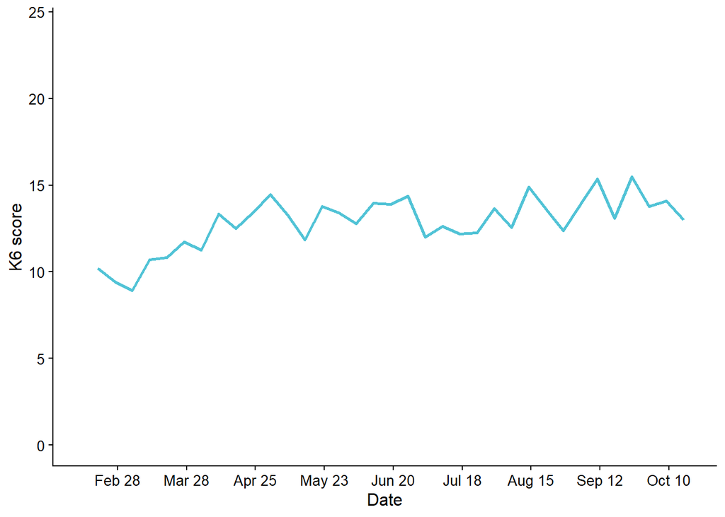

```r
# define x axis weekly breaks to match between graphs
weekly_breaks <- seq.Date(
  from = floor_date(min(df$week, na.rm=T),   "week", week_start = 1), # monday before first case
  to   = ceiling_date(max(df$week, na.rm=T), "week", week_start = 1), # monday after last case
  by   = "week")


k6_time <-
df %>% group_by(week) %>% summarise(K6 = mean(k6_tot)) %>%

ggplot(aes(x=week, y=K6)) +
  geom_line(color = "#3EBCD2", size = 1, alpha = 0.9, linetype = 1) +
  labs(x="Date", y="K6 score") +
  scale_x_date(
    date_breaks = "4 weeks",
    date_labels = "%b %d",
    limits      = c(min(weekly_breaks), max(weekly_breaks))
  ) +
  ylim(0,24) +
  theme_cowplot(12)

k6_time
```

**Can we map this to the COVID-19 evolution in Hong Kong?** Pulled COVID-19 daily cases, deaths etc. from Our World in Data during the data collection period (Feb 20 to Oct 19)

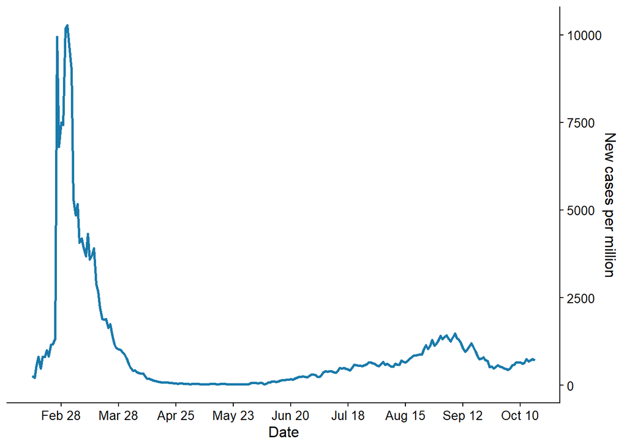

```r
covid_time <-
  ggplot(covid_df, aes(x=date, y=new_cases_per_million)) +
  geom_line(color = "#006BA2", size = 1, alpha = 0.9, linetype = 1) +
  labs(x="Date", y="New cases per million") +
  scale_x_date(
    date_breaks = "4 weeks",
    date_labels  = "%b %d",
    limits      = c(min(weekly_breaks), max(weekly_breaks))
    )+
  scale_y_continuous(position="right") +
  theme_cowplot(12)

covid_time
```

**Is there any correlation between K6 score and the severity of COVID-19 outbreak?**

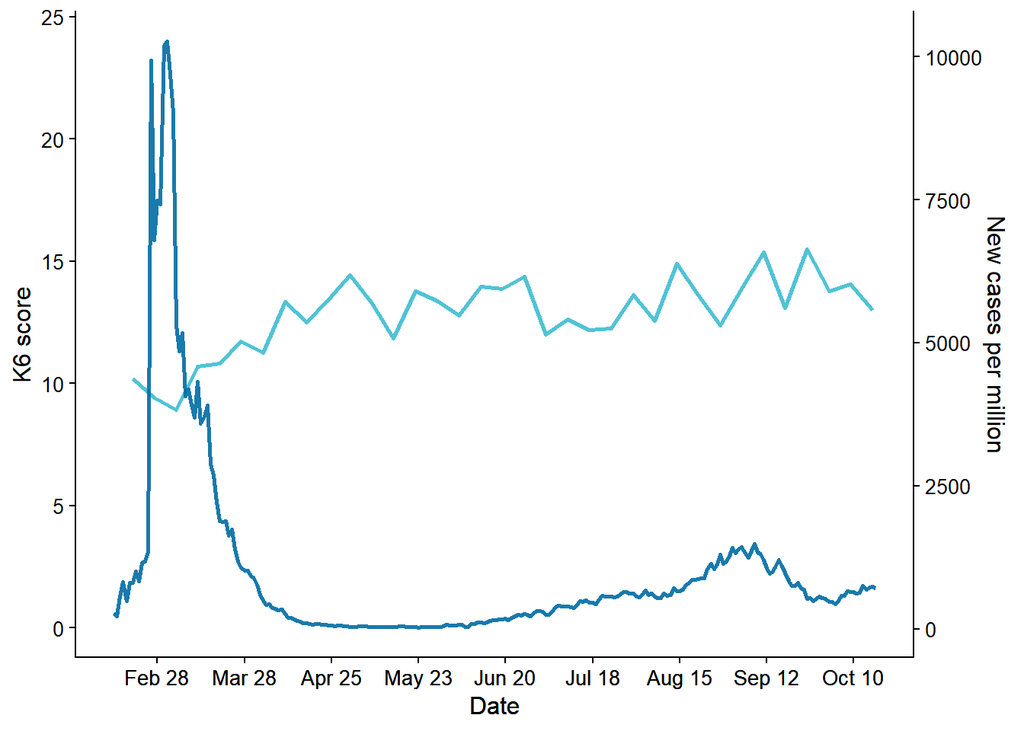

```r
aligned_k6_cov_plots <- align_plots(k6_time,covid_time,align = "hv", axis = "tblr")
ggdraw(aligned_k6_cov_plots[[1]]) + draw_plot(aligned_k6_cov_plots[[2]])
```

### Time correlation stratified by age group

**Does the K6 score of different age groups vary in pattern or trend over time?**

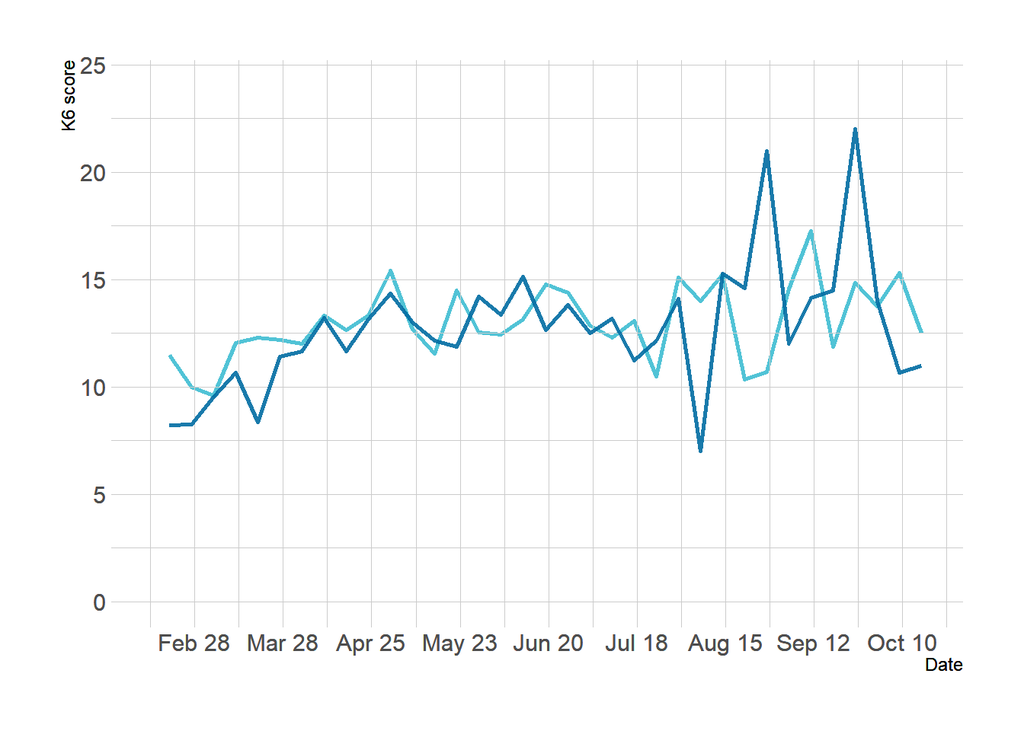

```r
k6_time_15_24 <- df %>% filter(youth_group=="15-24") %>% group_by(week) %>% summarise(K6 = mean(k6_tot)) %>%
ggplot(aes(x=week, y=K6)) +
  geom_line(color = "#3EBCD2", size = 1, alpha = 0.9, linetype = 1) +
  labs(x="Date", y="K6 score") +
  scale_x_date(
    date_breaks = "4 weeks",
    date_labels = "%b %d",
    limits      = c(min(weekly_breaks), max(weekly_breaks))
  ) +
  ylim(0,24)+
  theme_ipsum_rc(12)

k6_time_24 <- df %>% filter(youth_group==">24") %>% group_by(week) %>% summarise(K6 = mean(k6_tot)) %>%
ggplot(aes(x=week, y=K6)) +
  geom_line(color = "#006BA2", size = 1, alpha = 0.9, linetype = 1) +
  labs(x="Date", y="K6 score") +
  scale_x_date(
    date_breaks = "4 weeks",
    date_labels = "%b %d",
    limits      = c(min(weekly_breaks), max(weekly_breaks))
  ) +
  ylim(0,24)+
  theme_ipsum_rc(12)

aligned_k6_age_plots <- align_plots(k6_time_15_24,k6_time_24,align = "hv", axis = "tblr")
ggdraw(aligned_k6_age_plots[[1]]) + draw_plot(aligned_k6_age_plots[[2]])
```

### Time of day effects

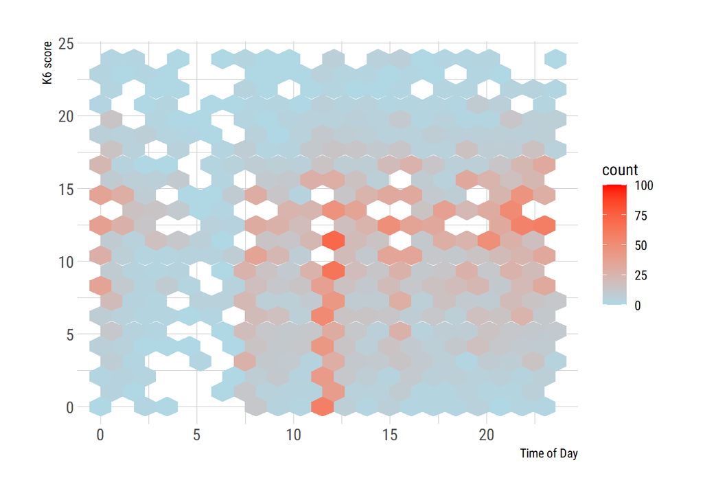

```r
df %>% ggplot(aes(time_of_day, k6_tot)) +
  stat_bin_hex(bins=20) +
  scale_fill_gradient(low = "lightblue", high = "red", limits = c(0, 100))+
  labs(x="Time of Day", y="K6 score") +
  theme_ipsum_rc()
```

## COVID-19 related events

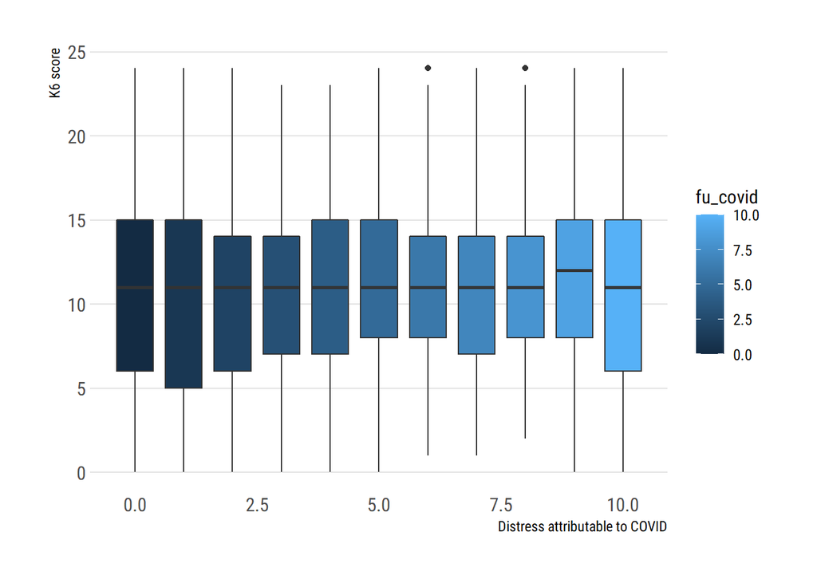

```r
df %>% ggplot(aes(fu_covid, k6_tot)) +
  geom_boxplot(aes(x=fu_covid, group=fu_covid, fill=fu_covid))+
  labs(x="Distress attributable to COVID", y="K6 score") +
  theme_ipsum_rc(grid="Y")
```

# Network analysis

## Estimate partial correlation network with EBIC

```r
# define k6 names
k6_names <- c("k6_nervous","k6_hopeless","k6_restless","k6_depressed","k6_effort","k6_worthless")

# select relevant columns from main df
net_df <- df %>% select(k6_1,k6_2,k6_3,k6_4,k6_5,k6_6,fu_covid,
                        covid_pos,covid_else_pos,covid_gov,finance_difficulty,lose_job)
net_df <- net_df %>% dplyr::rename('k6_nervous' = 'k6_1',
                          'k6_hopeless' = 'k6_2',
                          'k6_restless' = 'k6_3',
                          'k6_depressed' = 'k6_4',
                          'k6_effort' = 'k6_5',
                          'k6_worthless' = 'k6_6')


k6_df <- df %>% select(k6_1,k6_2,k6_3,k6_4,k6_5,k6_6)
k6_df <- k6_df %>% dplyr::rename('k6_nervous' = 'k6_1',
                          'k6_hopeless' = 'k6_2',
                          'k6_restless' = 'k6_3',
                          'k6_depressed' = 'k6_4',
                          'k6_effort' = 'k6_5',
                          'k6_worthless' = 'k6_6')

# define groups
factors <- rep(c("K6 Psychological Distress","COVID Related Stressors"),each=6)

# define nodes
items <- c("Nervous","Hopeless","Restless","Depressed","Effortful","Worthless",
           "Distress from COVID", "Self positive test", "Other positve test",
           "Mandated health measures", "Financial difficulty", "Job loss")

# estimate partial correlation network for k6 + fu + covid items
network <- estimateNetwork(net_df, default = "EBICglasso", corMethod = "spearman")
```

```
## Estimating Network. Using package::function:
##   - qgraph::EBICglasso for EBIC model selection
##     - using glasso::glasso
```

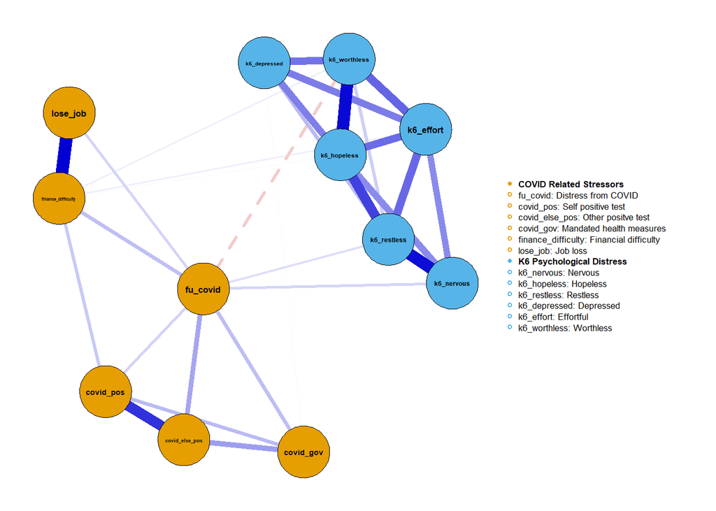

```r
plot(network,
     layout = "spring",
     groups = factors,
     label.cex = 0.7, # scalar on label size
     label.color = 'black', # string on label colors
     label.prop = 0.9, # proportion of the width of the node that the label scales

     # Edges (pp. 33-34)
     negDashed = T, # should negative edges be dashed?

     # Legend (p. 35-36)
     legend.cex = 0.27, # scalar of the legend
     legend.mode = 'style2', # default is 'style1'
     nodeNames = items, # names for each node to plot in legend

     # Generical graphical arguments (p. 36)
     font = 2)
```

```r
network
```

```
##
## === Estimated network ===
## Number of nodes: 12
## Number of non-zero edges: 33 / 66
## Mean weight: 0.05684488
## Network stored in x$graph
##
## Default set used: EBICglasso
##
## Use plot(x) to plot estimated network
## Use bootnet(x) to bootstrap edge weights and centrality indices
##
## Relevant references:
##
##      Friedman, J. H., Hastie, T., & Tibshirani, R. (2008). Sparse inverse covariance estimation with the graphical lasso. Biostatistics, 9 (3), 432-441.
##  Foygel, R., & Drton, M. (2010). Extended Bayesian information criteria for Gaussian graphical models.
##  Friedman, J. H., Hastie, T., & Tibshirani, R. (2014). glasso: Graphical lasso estimation of gaussian graphical models. Retrieved from https://CRAN.R-project.org/package=glasso
##  Epskamp, S., Cramer, A., Waldorp, L., Schmittmann, V. D., & Borsboom, D. (2012). qgraph: Network visualizations of relationships in psychometric data. Journal of Statistical Software, 48 (1), 1-18.
##  Epskamp, S., Borsboom, D., & Fried, E. I. (2016). Estimating psychological networks and their accuracy: a tutorial paper. arXiv preprint, arXiv:1604.08462.
```

```r
# estimate partial correlation network for k6 + covid items (no fu)
nofu_df <- df %>% select(k6_1,k6_2,k6_3,k6_4,k6_5,k6_6,
                        covid_pos,covid_else_pos,covid_gov,finance_difficulty,lose_job)

nofu_df <- nofu_df %>% dplyr::rename('k6_nervous' = 'k6_1',
                          'k6_hopeless' = 'k6_2',
                          'k6_restless' = 'k6_3',
                          'k6_depressed' = 'k6_4',
                          'k6_effort' = 'k6_5',
                          'k6_worthless' = 'k6_6')

nofu_net <- estimateNetwork(nofu_df, default = "EBICglasso", corMethod = "spearman")
```

```
## Estimating Network. Using package::function:
##   - qgraph::EBICglasso for EBIC model selection
##     - using glasso::glasso
```

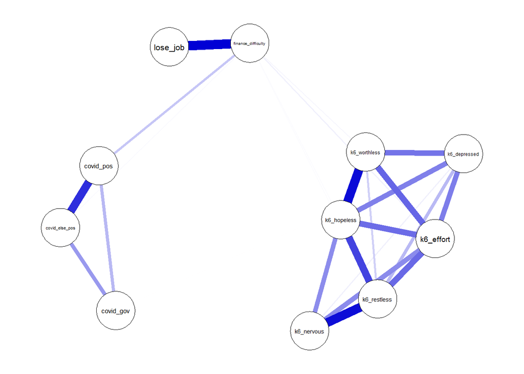

```r
plot(nofu_net)
```

## Bootstrap stability of edge weights

```r
bootnet_nonpar <- bootnet(network, nBoots = 1000, nCores = 8)
```

```
## Note: bootnet will store only the following statistics:  edge, strength, outStrength, inStrength
```

```
## Bootstrapping...
```

```
## Computing statistics...
```

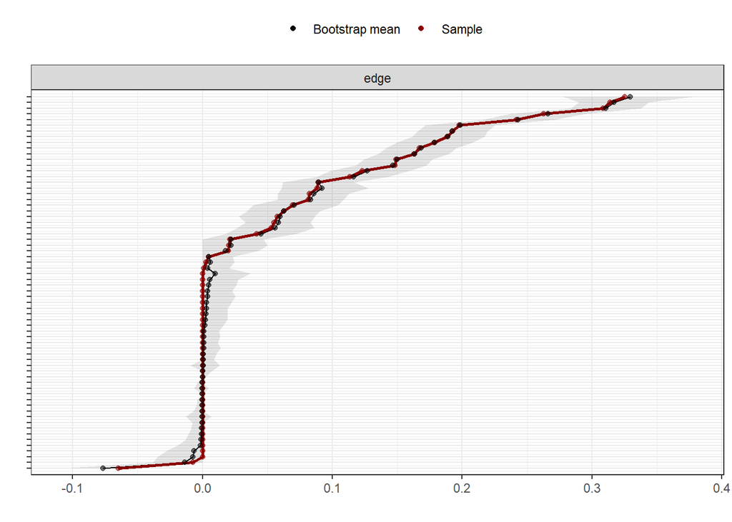

```r
plot(bootnet_nonpar, labels=FALSE,order="sample")
```

## Stability of centrality measures

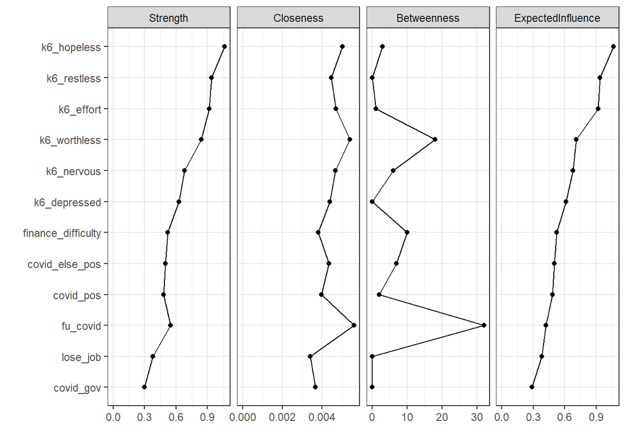

```r
centralityPlot(network, include = "all", orderBy = "ExpectedInfluence")
```

```r
bootnet_case_dropping <- bootnet(network,
                                 nBoots = 2500,
                                 type = "case",
                                 nCores = 8,
                                 statistics = c('strength',
                                                'expectedInfluence',
                                                'betweenness',
                                                'closeness'))
```

```
## Note: bootnet will store only the following statistics:  strength, expectedInfluence, betweenness, closeness
```

```
## Bootstrapping...
```

```
## Computing statistics...
```

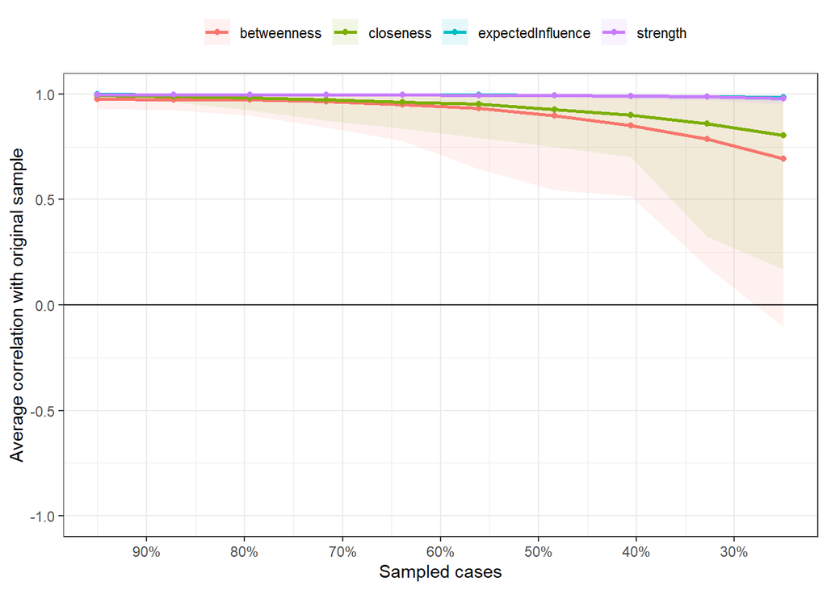

```r
plot(bootnet_case_dropping, 'all')
```

```r
corStability(bootnet_case_dropping)
```

```
## === Correlation Stability Analysis ===
##
## Sampling levels tested:
##    nPerson Drop%   n
## 1     1257  75.0 261
## 2     1648  67.2 233
## 3     2040  59.4 250
## 4     2431  51.7 252
## 5     2822  43.9 260
## 6     3213  36.1 270
## 7     3604  28.3 249
## 8     3995  20.6 253
## 9     4386  12.8 230
## 10    4778   5.0 242
##
## Maximum drop proportions to retain correlation of 0.7 in at least 95% of the samples:
##
## betweenness: 0.439
##   - For more accuracy, run bootnet(..., caseMin = 0.361, caseMax = 0.517)
##
## closeness: 0.594
##   - For more accuracy, run bootnet(..., caseMin = 0.517, caseMax = 0.672)
##
## expectedInfluence: 0.75 (CS-coefficient is highest level tested)
##   - For more accuracy, run bootnet(..., caseMin = 0.672, caseMax = 1)
##
## strength: 0.75 (CS-coefficient is highest level tested)
##   - For more accuracy, run bootnet(..., caseMin = 0.672, caseMax = 1)
##
## Accuracy can also be increased by increasing both 'nBoots' and 'caseN'.
```

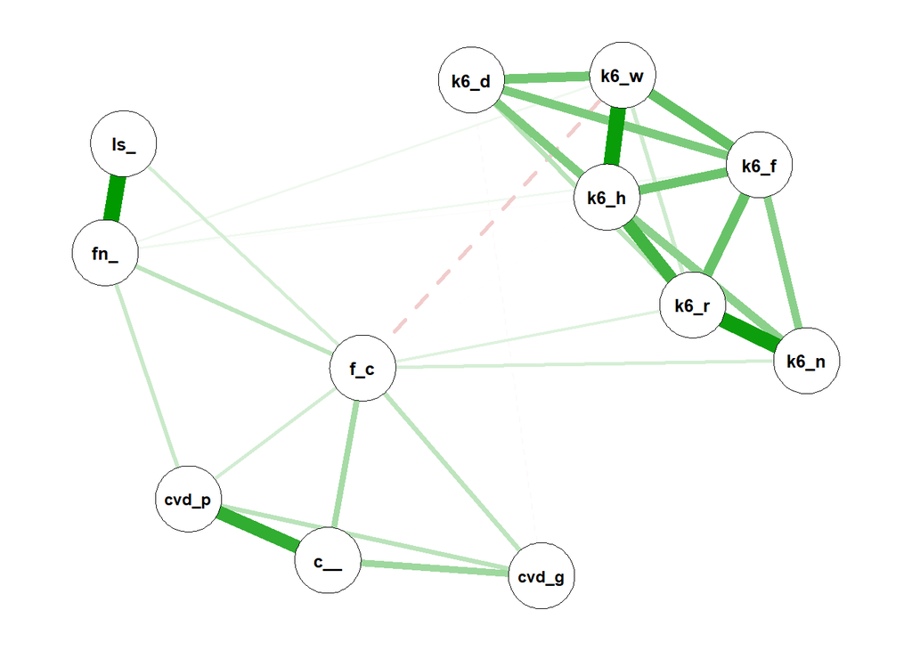

```r
network_plot<-
  qgraph(network$graph, layout="spring",
         label.cex = 0.7, # scalar on label size
         #groups = factors,
     label.color = 'black', # string on label colors
     label.prop = 0.9, # proportion of the width of the node that the label scales

     # Edges (pp. 33-34)
     negDashed = T, # should negative edges be dashed?

     # Legend (p. 35-36)
     legend.cex = 0.27, # scalar of the legend
     legend.mode = 'style2', # default is 'style1'
     #nodeNames = items, # names for each node to plot in legend

     # Generical graphical arguments (p. 36)
     font = 2)
```

```r
qgraph(network_plot,filetype='pdf',height=5,width=10)
```

```
## Output stored in C:/Users/kris/OneDrive - connect.hku.hk/Documents/R directory/psi/headwind/RAT/kris_rat_analysis/qgraph.pdf
```

```r
k6_network <- estimateNetwork(k6_df, default = "EBICglasso", corMethod = "spearman")
```

```
## Estimating Network. Using package::function:
##   - qgraph::EBICglasso for EBIC model selection
##     - using glasso::glasso
```

```
## Note: Network with lowest lambda selected as best network: assumption of sparsity might be violated.
```

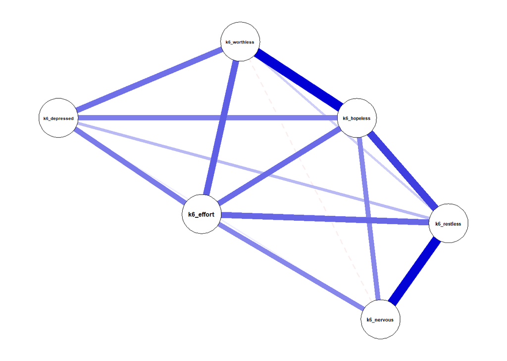

```r
plot(k6_network,layout = "spring",
     label.cex = 0.7, # scalar on label size
     label.color = 'black', # string on label colors
     label.prop = 0.9, # proportion of the width of the node that the label scales

     # Edges (pp. 33-34)
     negDashed = T, # should negative edges be dashed?

     # Legend (p. 35-36)
     legend.cex = 0.27, # scalar of the legend
     legend.mode = 'style2', # default is 'style1'
     #nodeNames = items, # names for each node to plot in legend

     # Generical graphical arguments (p. 36)
     font = 2)
```

*krisyalouie.hw@gmail.com*